# Comenzando con análisis textual en R Studio

#### **Romina De León**

rdeleon@conicet.gov.ar

Durante esta ejercitación utilizaremos lo visto en las unidades previas: funciones básicas en R para manipulación de datos, dataframe, vectores, etc, formas de iteración, formas de visualizaciones, y también una aproximación al análisis textual.

EL corpus con el que trabajaremos lo he dejado en forma de zip en la carpeta del campus. El mismo está compuesto por las plataformas electorales de candidatos y candidatas a la presidencia de Argentina, que fueron publicadas en la web oficial luego del cierre de listas el 24 de junio de 2023. Estas se encontraban en formato PDF pero fueron pasadas a texto plano para poder llevar adelante esta ejercitación[^1].

Cada archivo fue denominado como `nombre de la plataforma` con extensión `.txt`, que indica texto plano.

Inicialmente, partiremos con la preparación de nuestro entorno de trabajo:

```r
rm(list = ls()) #limpiamos el entorno

getwd() #obtenemos la dirección donde estoy ubicada
```

```
## [1] "C:/~/corpus_ej2"
```

```r
pathwd <- getwd() #adjudico a esta variable la dirección que quiero guardar, esto puede modificarse poniendo entre " " la dirección necesaria

setwd(pathwd) #seteo mi lugar de trabajo
```

**Primero paso**: Se puede descargar y descomprimir como lo realizas habitualmente la carpeta directamente del campus, o sino mediante el comando `download.file` descargarás el archivo *.zip con la url entre comillas, luego indicarás el nombre del archivo y finalmente con el parámetro **wget** se indica el método utilizado para realizar la descarga, **aclaración** en Windows debes cambiarlo por **wininet**. Luego, descomprime el archivo con el comando `unzip`. A continuación ingresa a tu carpeta de trabajo.

```r
download.file("https://github.com/hdlabconicet/Estilometria-con-R/raw/gh-pages/corpus_ej2.zip", destfile="corpus_ej2.zip", "wget") # Aclaración para Windows reemplazar 'wget' por "wininet"

unzip("corpus_ej2.zip")

setwd("corpus_ej2/") # Ingresa a la carpeta que se ha creado, recuerda que puedes incluso crear otra carpeta para datos de entrada (input) y datos de salida (output) para cargar y guardar tus archivos
```

El paso a seguir es llamar a las librerías que se utilizarán:

```r
library(tidytext) #recuerda que si no está instalada la librería primero debes hacerlo mediante install.packages()
library(tidyverse)
library(dplyr)
```

Una vez instalados estos requerimientos, llamaremos a la función `list.file` para corroborar que los archivos necesarios se encuentran en la carpeta donde estás trabajando.

```r
list.files(, pattern='txt') #no completo la dirección de la carpeta porque voy a trabajar en ella, solo aclaro que me devuelva la lista de los archivos txt
```

En un segundo paso, crearemos una nueva **lista**, a la que puedes llamar `archivos`, cuyos elementos serán los textos planos dentro de la carpeta **corpus_ej2**, para ello, utilizarás, nuevamente, la función `list.files`, y le indicarás que tipo de archivo debe contener, **txt**, con la declaración `pattern`. Recuerda estar trabajando en la carpeta donde se encuentran tus archivos, sino deberás incorporar un declaración que indique la ubicación, `path =`, por ejemplo: `list.files(path = "discurso", pattern = "\\.txt$")`.

```r
archivos <- list.files(pattern = "\\.txt$", full.names = TRUE)

archivos #corroboramos que la lista es correcta
```

```
##  [1] "./coalicion_paz_democracia_soberania.txt"
##  [2] "./frente_izquierda_trabajadores.txt"
##  [3] "./frente_liber_ar.txt"
##  [4] "./hacemos_nuestro_pais.txt"
##  [5] "./juntos_cambio_orden_nacional.txt"
##  [6] "./libertad_avanza.txt"
##  [7] "./libres_sur.txt"
##  [8] "./movimiento_accion_vecinal.txt"
##  [9] "./movimiento_izquierda_juventud_dignidad.txt"
## [10] "./movimiento_socialismo.txt"
## [11] "./patria_unida.txt"
## [12] "./politica_obrera.txt"
## [13] "./principios_valores_tierra_techo_trabajo.txt"
## [14] "./union_centro_democratico.txt"
## [15] "./union_patria.txt"
```

```r
class(archivos) #la función 'class()' devuelve el tipo de objeto, en este caso podrás ver que se trata de una lista de caracteres
```

```
## [1] "character"
```

```r
length(archivos) #la función 'length()' permite obtener el tamaño del objeto que se incluye dentro de los paréntesis
```

```
## [1] 15
```

Ahora, para facilitar la visualización de cada texto en los siguientes pasos, eliminaremos lo que no es necesario del nombre de cada archivo. Para ello, se utilizará la función `gsub`, de gran utilidad para limpieza de datos que está incluida por defecto en **R**. Los parámetros indicarán, según orden de escritura, caracteres que se eliminarán (\\. será para indicar que se busca un **`.`** y no otro carácter según las reglas de expresión regular[^3]), los que se agregarán (las doble comillas indican que no se agregará nada), y finalmente, con **perl**, se determina que se utilicen las reglas de expresiones regulares[^4].

```r
textos_archivo <- gsub("\\.txt", "", archivos, perl = TRUE)

#Ahora llama a la lista para corroborar que se ha realizado la limpieza

textos_archivo
```

```
##  [1] "./coalicion_paz_democracia_soberania"
##  [2] "./frente_izquierda_trabajadores"
##  [3] "./frente_liber_ar"
##  [4] "./hacemos_nuestro_pais"
##  [5] "./juntos_cambio_orden_nacional"
##  [6] "./libertad_avanza"
##  [7] "./libres_sur"
##  [8] "./movimiento_accion_vecinal"
##  [9] "./movimiento_izquierda_juventud_dignidad"
## [10] "./movimiento_socialismo"
## [11] "./patria_unida"
## [12] "./politica_obrera"
## [13] "./principios_valores_tierra_techo_trabajo"
## [14] "./union_centro_democratico"
## [15] "./union_patria"
```

```r
textos_archivo <- gsub("./", "", textos_archivo, perl = TRUE) #esta línea la he agregado porque en mi lista me queda ./ y de esta manera lo elimino, si no es tu caso no hace falta

textos_archivo
```

```
##  [1] "coalicion_paz_democracia_soberania"
##  [2] "frente_izquierda_trabajadores"
##  [3] "frente_liber_ar"
##  [4] "hacemos_nuestro_pais"
##  [5] "juntos_cambio_orden_nacional"
##  [6] "libertad_avanza"
##  [7] "libres_sur"
##  [8] "movimiento_accion_vecinal"
##  [9] "movimiento_izquierda_juventud_dignidad"
## [10] "movimiento_socialismo"
## [11] "patria_unida"
## [12] "politica_obrera"
## [13] "principios_valores_tierra_techo_trabajo"
## [14] "union_centro_democratico"
## [15] "union_patria"
```

A continuación, armaremos un vector denominado `partidos`, que será utilizado para armar una matriz, `plataformas`, que será a modo de recordatorio de los nombres de cada agrupación y útil para recortar estos dentro del dataframe en el que trabajaremos más adelante.

```r
partidos <- c("part_01", "part_02", "part_03", "part_04", "part_05", "part_06", "part_07", "part_08", "part_09", "part_10", "part_11", "part_12", "part_13", "part_14", "part_15")

plataformas <- cbind(partidos, textos_archivo)

plataformas
```

```
##       partidos  textos_archivo
##  [1,] "part_01" "coalicion_paz_democracia_soberania"
##  [2,] "part_02" "frente_izquierda_trabajadores"
##  [3,] "part_03" "frente_liber_ar"
##  [4,] "part_04" "hacemos_nuestro_pais"
##  [5,] "part_05" "juntos_cambio_orden_nacional"
##  [6,] "part_06" "libertad_avanza"
##  [7,] "part_07" "libres_sur"
##  [8,] "part_08" "movimiento_accion_vecinal"
##  [9,] "part_09" "movimiento_izquierda_juventud_dignidad"
## [10,] "part_10" "movimiento_socialismo"
## [11,] "part_11" "patria_unida"
## [12,] "part_12" "politica_obrera"
## [13,] "part_13" "principios_valores_tierra_techo_trabajo"
## [14,] "part_14" "union_centro_democratico"
## [15,] "part_15" "union_patria"
```

Posteriormente, realizaremos el cambio de nombre dentro del objeto, por medio de la función `sprintf`, que toma una cadena y un conjunto de argumentos, para devolver una cadena de caracteres con el texto formateado, además le estoy aclarando que quiero que se llame part_ y un número según nuestra lista `textos_archivo`, si le digo que utilice dos digitos, por medio de %02d, utilizando expresiones regulares.

```r
textos_archivo #solo corroboro mi lista con archivos
```

```
##  [1] "coalicion_paz_democracia_soberania"
##  [2] "frente_izquierda_trabajadores"
##  [3] "frente_liber_ar"
##  [4] "hacemos_nuestro_pais"
##  [5] "juntos_cambio_orden_nacional"
##  [6] "libertad_avanza"
##  [7] "libres_sur"
##  [8] "movimiento_accion_vecinal"
##  [9] "movimiento_izquierda_juventud_dignidad"
## [10] "movimiento_socialismo"
## [11] "patria_unida"
## [12] "politica_obrera"
## [13] "principios_valores_tierra_techo_trabajo"
## [14] "union_centro_democratico"
## [15] "union_patria"
```

```r
new_names <- sprintf("part_%02d", 1:length(textos_archivo)) #utilizo este código para nuevo nombre

textos_archivo <- new_names #asigno los nuevos nombres


textos_archivo #corroboro que se realizó correctamente
```

```
##  [1] "part_01" "part_02" "part_03" "part_04" "part_05" "part_06" "part_07"
##  [8] "part_08" "part_09" "part_10" "part_11" "part_12" "part_13" "part_14"
## [15] "part_15"
```

Cuarto paso, con la lista de textos acorde para continuar el ejercicio, procedemos a armar un `tibble`, este objeto es muy similar a los data.frame presentados en la unidad anterior, pues es rectangular, organizado en filas y columnas, y pertenece al paquete `tidyverse`.

Existen tres diferencias entre los **data.frame** y los **tibble**, la primera es como se muestran en consola; segunda, los tibble eliminan por defecto **rownames**, e incluso no se recomienda su uso, para evitar problemas de compatibilidad principalmente con bases de datos SQL; por último, no convierte a las **string** (cadenas de caracteres) en factores. Igualmente, ambos objetos son intercambiables[^5].

Armaremos el tibble con tres columnas, la primera y última tendrán caracteres dentro de sus variables, y `parrafo` será numérica, como se muestra a continuación:

```r
mensajes <- tibble(textos_archivo = character(),
                   parrafo = numeric(),
                   texto = character())

#Si llamas a "mensajes" comprobarás que figura como vacío, esto es porque aún no se ha completado con datos, ello lo realizarás en el próximo paso.

mensajes
```

```
## # A tibble: 0 × 3
## # ℹ 3 variables: textos_archivo <chr>, parrafo <dbl>, texto <chr>
```

Para poder completar el tibble **mensajes** que creamos, lo hacemos mediante una iteración con el bucle `for`, que permite repetir instrucciones, evaluando el mismo código para cada elemento de un vector o lista.

En este ejercicio, se le indica que comience la iteración en 1 hasta el tamaño (**length**) de `archivos`. Luego, armará en el objeto `discurso` lo que leerá con la función `read_lines`, allí se indicará que con la función `paste` junte los textos dentro de tu carpeta de trabajo, *importante añadir esa dirección*, con el contenido de `archivos[i]` , cuyo valor cambiará en cada repetición del bucle. El parámetro `sep =` será para indicar que los pegue con “**/“** .

Paso siguiente, convertiremos lo que acaba de leer en una nueva tabla, otra tibble llamada `temporal`, tal como hiciste con la anterior de `mensajes`, indicando que complete con cada texto. La primer columna, `parrafo` indicará el número de párrafos de cada texto, se lo adjudicará con la función `seq_along` que contará hasta el número máximo en el objeto `discurso` y por último, en `texto` se agregará cada párrafo. Para finalizar la repetición, indicarás que en **mensajes** se sume la tabla `temporal`, mediante la función **bind_rows**.

```r
#Iteración

for (i in 1:length(archivos)){
  discurso <- read_lines(paste(pathwd, #recuerden que uso pathwd porque es donde me situé y están mis archivos, sino debes incluir tu dirección
                               archivos[i],
                               sep = "/"))
  temporal <- tibble(textos_archivo = textos_archivo[i],
                     parrafo = seq_along(discurso),
                     texto = discurso)
  mensajes <- bind_rows(mensajes, temporal)
}

mensajes #corrobora que se creó correctamente la tabla
```

```
## # A tibble: 1,131 × 3
##    textos_archivo parrafo texto
##    <chr>            <dbl> <chr>
##  1 part_01              1 "LISTA COALICION PAZ DEMOCRACIA Y SOBERANIA"
##  2 part_01              2 ""
##  3 part_01              3 "Estamos viviendo en nuestro país un momento político…
##  4 part_01              4 ""
##  5 part_01              5 "NUESTRAS BASES DE ACCIONPOLÍTICA"
##  6 part_01              6 "Estabilidad Económica “Un País Previsible con salari…
##  7 part_01              7 "Seguridad: Debe ser garantizada por el estado. “Defe…
##  8 part_01              8 "Reforma social del estado: “PENSAR LA ARGENTINA”"
##  9 part_01              9 ""
## 10 part_01             10 "ESTABILIDAD ECONÓMICA"
## # ℹ 1,121 more rows
```

```r
plataformas
```

```
##       partidos  textos_archivo
##  [1,] "part_01" "coalicion_paz_democracia_soberania"
##  [2,] "part_02" "frente_izquierda_trabajadores"
##  [3,] "part_03" "frente_liber_ar"
##  [4,] "part_04" "hacemos_nuestro_pais"
##  [5,] "part_05" "juntos_cambio_orden_nacional"
##  [6,] "part_06" "libertad_avanza"
##  [7,] "part_07" "libres_sur"
##  [8,] "part_08" "movimiento_accion_vecinal"
##  [9,] "part_09" "movimiento_izquierda_juventud_dignidad"
## [10,] "part_10" "movimiento_socialismo"
## [11,] "part_11" "patria_unida"
## [12,] "part_12" "politica_obrera"
## [13,] "part_13" "principios_valores_tierra_techo_trabajo"
## [14,] "part_14" "union_centro_democratico"
## [15,] "part_15" "union_patria"
```

```r
#solo para recordar que partidos corresponden a la numeracion de part_numero
```

Este sexto paso, será para proceder con la tokenización del corpus, es decir extraer sus unidades de análisis. Para ello, se utilizará la función `unnest_tokens` que se encuentra dentro del paquete **tidytext**; se indicará que a cada fila de **parrafo**, lo separe a nivel de palabra según la columna **texto**.

**mensajes_palabras** estará formado por tres columnas, una que indicará el texto, la otra el número de párrafo y finalmente, las palabras de cada uno, pero separadas. Recuerda que el operador **pipe (%>%)** fue presentado en la primera unidad.

```r
mensajes_palabras <- mensajes %>%
  unnest_tokens(palabra, texto)


mensajes_palabras
```

```
## # A tibble: 34,395 × 3
##    textos_archivo parrafo palabra
##    <chr>            <dbl> <chr>
##  1 part_01              1 lista
##  2 part_01              1 coalicion
##  3 part_01              1 paz
##  4 part_01              1 democracia
##  5 part_01              1 y
##  6 part_01              1 soberania
##  7 part_01              3 estamos
##  8 part_01              3 viviendo
##  9 part_01              3 en
## 10 part_01              3 nuestro
## # ℹ 34,385 more rows
```

Como siguiente paso, se eliminarán las palabras vacías, que no serán útil en este ejercicio, pero si pueden servir para otros análisis; asimismo, lo realizarás para continuar con la parte de ejercitación que solicitaré como extra. Para ello, se armará una una tabla con las palabras que se obtienen de la función **get_stopwords** que forma parte del paquete **tidytext**, y se aclarará que se utilice en español.

```r
stopwords1 <- get_stopwords("es")

stopwords1
```

```
## # A tibble: 308 × 2
##    word  lexicon
##    <chr> <chr>
##  1 de    snowball
##  2 la    snowball
##  3 que   snowball
##  4 el    snowball
##  5 en    snowball
##  6 y     snowball
##  7 a     snowball
##  8 los   snowball
##  9 del   snowball
## 10 se    snowball
## # ℹ 298 more rows
```

Paso siguiente, se le indicará que cambie la columna **word** por **palabra**, mediante la función `rename`, que forma parte del paquete **dplyr**, que a su vez pertenece a **tidyverse**, es útil para cambiar el nombre de variables u objetos. Cuestión que debe considerarse al momento de renombrar, es que primero debe escribirse el nuevo término, y a continuación el que se va a cambiar. Este paso es importante para poder eliminar las palabras vacías de mensajes_palabras.

```r
stopwords1 <- stopwords1 %>%
rename(palabra = word)
```

Ahora, para poder obtener una nueva lista con palabras vacías excluidas, se usará la función `anti_join` que compara las columnas con el mismo nombre, en este caso **palabra** y elimina los elementos que coinciden. Cuando finalice la ejecución, aparece un mensaje que significa que las dos listas tienen iguales elementos en esas columnas, en caso contraria, devolverá mensaje de error.

```r
mensajes_sin_vacias <- mensajes_palabras %>%
anti_join(stopwords1)
```

Como paso siguiente, se procederá a la limpieza de la lista **mensajes_palabras** y **mensajes_sin_vacias**. Para ello, se eliminarán dígitos, palabras con menos de tres caracteres, celdas sin caracteres y las que contengan puntos, todo ello se realizará en la columna **palabra**. Por lo cual, se utilizarán las siguientes funciones:

- **mutate**, que crea, modifica y elimina columnas según ciertos parámetros que se le adjudican, se encuentra dentro del paquete **tidyverse**. En este caso se le sumará **str_remove_all** (función que se utiliza para eliminar coincidencias en una cadena de caracteres) para que elimine en la columna **palabra** los números que aparezcan.
- **filter**, será para filtrar las palabras con menos de tres caracteres, con la ayuda de **nchar** que cuenta el número de caracteres; también se utilizará para eliminar los espacios con valores de caracteres vacíos y cuando encuentre un **.** o **n°** (símbolo de número que figura en los textos).

Repetirás las limpieza en las dos listas, recuerda guardar las que no fueron limpias, adjudicando nuevos nombres a las que si se hayan limpiado.

```r
mensajes_pal_limpio <- mensajes_palabras %>%
mutate(palabra = str_remove_all(palabra, "\\d+")) %>%
filter(nchar(palabra) >= 3) %>% #en este item puedo dejar que sea estrictamente mayor a 3, pero lo he dejado como igual o mayor porque había algunas palabras que podrían ser de utilidad
filter(palabra != "") %>%
filter(palabra != ".") %>%
filter(palabra != "n°")

mensajes_pal_limpio
```

```
## # A tibble: 23,455 × 3
##    textos_archivo parrafo palabra
##    <chr>            <dbl> <chr>
##  1 part_01              1 lista
##  2 part_01              1 coalicion
##  3 part_01              1 paz
##  4 part_01              1 democracia
##  5 part_01              1 soberania
##  6 part_01              3 estamos
##  7 part_01              3 viviendo
##  8 part_01              3 nuestro
##  9 part_01              3 país
## 10 part_01              3 momento
## # ℹ 23,445 more rows
```

Indica nuevo nombre a esta tabla que se ha limpiado. Esta nueva tabla será útil para realizar la parte de ejercitación extra.

```r
mensajes_limpio <- mensajes_sin_vacias %>%
mutate(palabra = str_remove_all(palabra, "\\d+")) %>%
filter(nchar(palabra) >= 3) %>%
filter(palabra != "") %>%
filter(palabra != ".") %>%
filter(palabra != "n°")


mensajes_limpio
```

```
## # A tibble: 17,642 × 3
##    textos_archivo parrafo palabra
##    <chr>            <dbl> <chr>
##  1 part_01              1 lista
##  2 part_01              1 coalicion
##  3 part_01              1 paz
##  4 part_01              1 democracia
##  5 part_01              1 soberania
##  6 part_01              3 viviendo
##  7 part_01              3 país
##  8 part_01              3 momento
##  9 part_01              3 político
## 10 part_01              3 requiere
## # ℹ 17,632 more rows
```

En el paso que sigue, se dará inicio a los análisis de frecuencia y gráficos de los textos del corpus. Para lo cual, primero se contará las palabras que se encuentran dentro de la columna **palabra** en **mensajes_pal_limpio**, por medio de la función **count**, que también pertenece al paquete **tidyverse**, y presentará la frecuencia absoluta de cada una, o sea la cantidad de veces que se repite.

```r
mensajes_pal_limpio %>%
  count(palabra, sort = TRUE)
```

```
## # A tibble: 6,113 × 2
##    palabra       n
##    <chr>     <int>
##  1 los         708
##  2 que         702
##  3 las         655
##  4 del         518
##  5 para        428
##  6 una         372
##  7 con         352
##  8 por         311
##  9 como        140
## 10 argentina   112
## # ℹ 6,103 more rows
```

```r
nrow(mensajes_palabras) / length(archivos)
```

```
## [1] 2293
```

```r
mensajes_frec_limpio <- mensajes_pal_limpio %>%
  count (palabra, sort = TRUE) %>%
  mutate (relativa = n / sum(n))

mensajes_frec_limpio
```

```
## # A tibble: 6,113 × 3
##    palabra       n relativa
##    <chr>     <int>    <dbl>
##  1 los         708  0.0302
##  2 que         702  0.0299
##  3 las         655  0.0279
##  4 del         518  0.0221
##  5 para        428  0.0182
##  6 una         372  0.0159
##  7 con         352  0.0150
##  8 por         311  0.0133
##  9 como        140  0.00597
## 10 argentina   112  0.00478
## # ℹ 6,103 more rows
```

También, podrías pedir que devuelva la frecuencia por cada texto, para ello, se deberá agrupar por cada uno mediante la función **group_by**, del paquete **tidyverse**, únicamente indicando que debe considerar la lista de textos, antes preparada; luego del cálculo de la frecuencia absoluta, debe crearse una nueva columna para la frecuencia relativa, y finalmente que desagrupe los datos, con **ungroup()**. Todo ello, será guardado en otra tabla **frecuencia_text_arch**:

```r
frecuencia_text_arch <- mensajes_pal_limpio %>%
           group_by(textos_archivo) %>%
           count(palabra, sort = T) %>%
           mutate(relative = n / sum(n)) %>%
           ungroup()

frecuencia_text_arch
```

```
## # A tibble: 11,134 × 4
##    textos_archivo palabra     n relative
##    <chr>          <chr>   <int>    <dbl>
##  1 part_12        del       166   0.0307
##  2 part_05        que       154   0.0358
##  3 part_12        los       153   0.0283
##  4 part_12        las       147   0.0272
##  5 part_05        los       130   0.0302
##  6 part_12        por       122   0.0226
##  7 part_12        que       122   0.0226
##  8 part_12        una       122   0.0226
##  9 part_05        para      109   0.0253
## 10 part_05        las       107   0.0249
## # ℹ 11,124 more rows
```

Ahora, para visualizar estos datos calculados realizarás un gráfico, donde se presentará la frecuencia por cada texto, con la función **ggplot**, que fue convocada al principio de la práctica con el paquete **tidyverse**, se le indicará que se graficará en barras, mediante el parámetro **geom_bar**, luego se indicará con **aes**, el contenido de los eje **X** e **Y**, en ese orden; y por último, con **stat**, que tipo de transformación estadísticas tendrán los datos. Recuerda que hemos trabajado con mensajes_pal_limpio y mediante `group_by` los reunimos según los elementos de la columna textos_archivo:

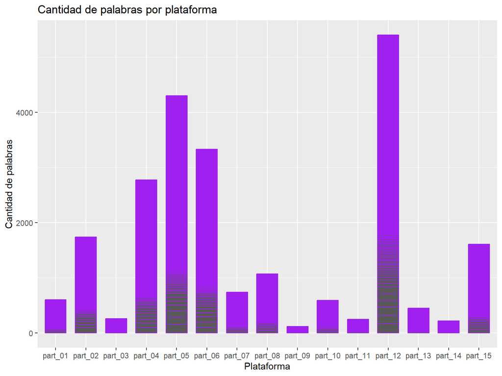

```r
mensajes_pal_limpio %>%
  group_by(textos_archivo) %>%
  count(palabra, sort = T) %>%
  ggplot() +
  geom_bar(aes(x = textos_archivo, y = n),
           stat = 'identity', , width = 0.7, color = 'purple') +
  labs(    y = "Cantidad de palabras",
    x = "Plataforma",
    title = "Cantidad de palabras por plataforma"
  )
```

```r
# con este comando puedes guardar tu gráfico: ggsave("mensajes_pal_limpio.png")
```

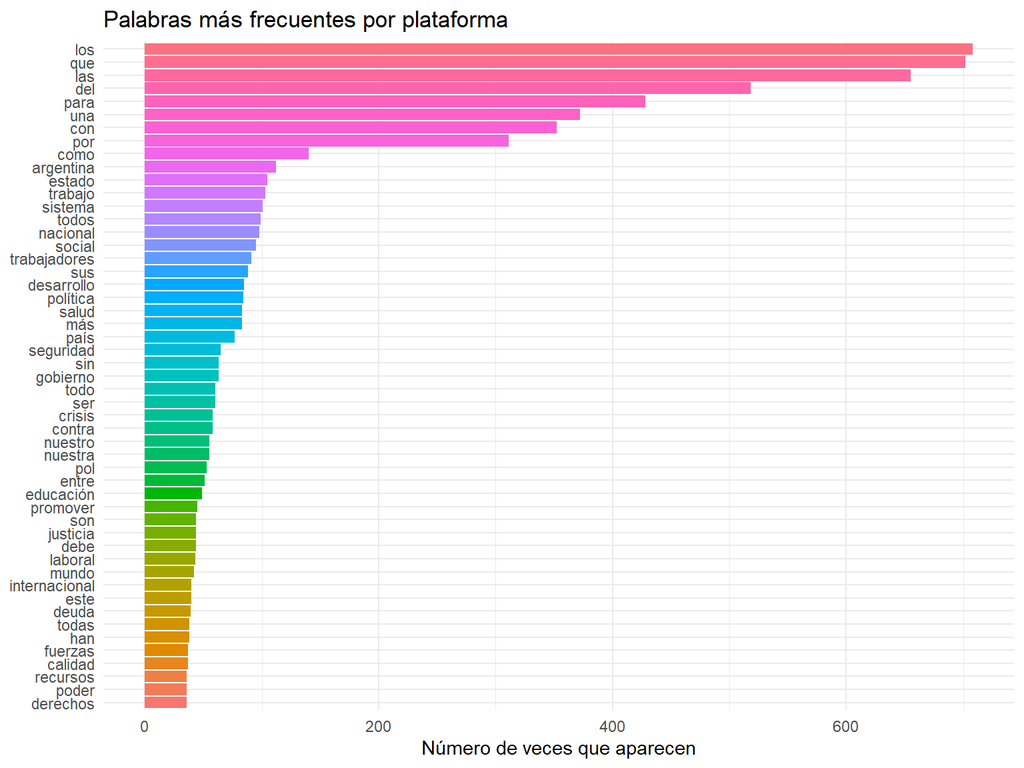

```r
mensajes_pal_limpio %>%
count(palabra, sort = T) %>%
filter(n > 35) %>%
mutate(palabra = reorder(palabra, n)) %>%
ggplot(aes(x = palabra, y = n, fill = palabra)) +
geom_bar(stat="identity") +
theme_minimal() +
theme(legend.position = "none") +
ylab("Número de veces que aparecen") +
xlab(NULL) +
ggtitle("Palabras más frecuentes por plataforma") +
coord_flip()
```

```r
ggsave("mensajes_palabras.png")
```

Un gráfico interesante podría realizarse teniendo en cuenta los mensajes limpios, es decir con las stopwords eliminadas, pero observando que sucede en cada plataforma, observa que solo le he indicado que `fill` sea diferenciado por partido.

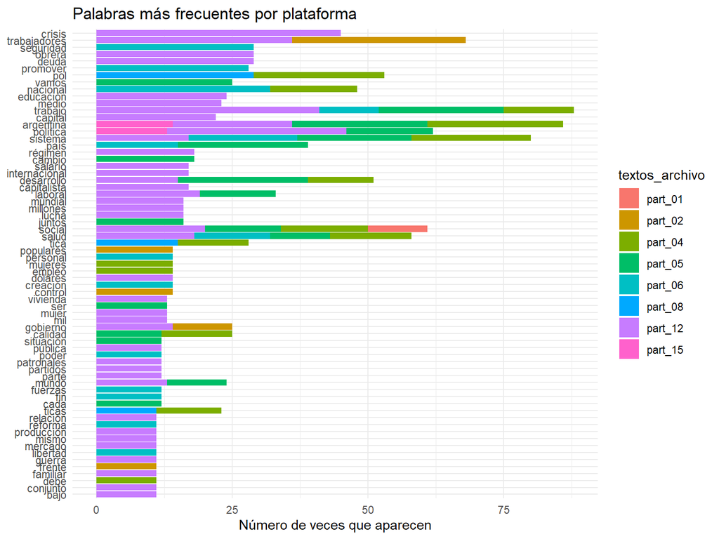

```r
mensajes_limpio %>%
   count(palabra, textos_archivo, sort = T) %>%
  filter(n > 10) %>%
  mutate(palabra = reorder(palabra, n)) %>%
  ggplot(aes(x = palabra, y = n, fill = textos_archivo)) +
  geom_bar(stat = "identity") +
  theme_minimal() +
  ylab("Número de veces que aparecen") +
  xlab(NULL) +
  ggtitle("Palabras más frecuentes por plataforma") +
  coord_flip()
```

Otra utilidad, que ha sido explicada en la parte teórica de la **Unidad 2**, es la Ley de Zipf, por lo cual, se reorganizarán los parámetros de ggplot para poder apreciar la relación entre cada palabra y su frecuencia.

Para ello, primero se armará una tabla con **mensajes_palabras**, con columnas con frecuencia absoluta = **n** y frecuencia relativa, sumada una última columna, que indicará el orden de palabras en forma descendente, o el número de filas, llamada **Clasificacion**.

```r
mensajes_frecuencias <- mensajes_palabras %>%
  count (palabra, sort = TRUE) %>%
  mutate (relativa = n / sum(n)) %>%
   mutate(Clasificacion = row_number())

mensajes_frecuencias
```

```
## # A tibble: 6,272 × 4
##    palabra     n relativa Clasificacion
##    <chr>   <int>    <dbl>         <int>
##  1 de       2661   0.0774             1
##  2 la       1887   0.0549             2
##  3 y        1523   0.0443             3
##  4 el        981   0.0285             4
##  5 en        772   0.0224             5
##  6 los       708   0.0206             6
##  7 que       702   0.0204             7
##  8 a         691   0.0201             8
##  9 las       655   0.0190             9
## 10 del       518   0.0151            10
## # ℹ 6,262 more rows
```

Para realizar el gráfico con dichos datos, se utilizará la tabla anterior, y se indicará en la tercera línea, mediante **geom_line** la forma en que va a realizar la línea del gráfico; y en las últimas dos, se indicará que en ambos ejes se usará la escala logarítimica.

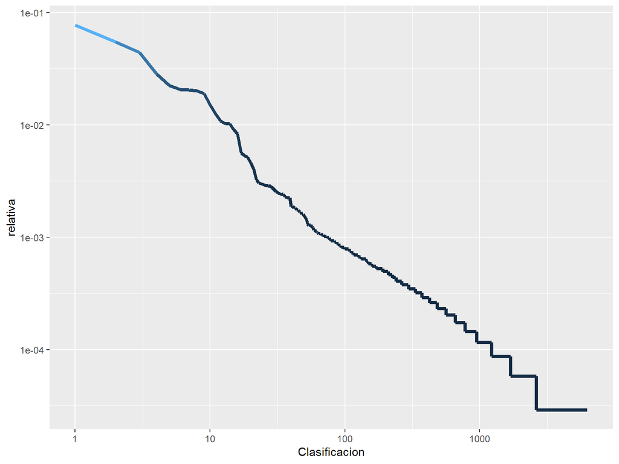

```r
mensajes_frecuencias %>%
  ggplot(aes(Clasificacion, relativa, color = n)) +
  geom_line(size = 1.5, alpha = 1.8, show.legend = FALSE) +
  scale_x_log10() +
  scale_y_log10()
```

Hasta acá sería la ejercitación que te propongo, ahora mi propuesta es que realicen análisis y gráficos, con mensajes donde se han realizado la limpieza de palabras vacías y que comparen los datos.  
Por otro lado, como ejercitación extra podrían intentar agrupar según algunas palabras los archivos del corpus.  
Pueden compartir sus script, recuerden guardarlo como *.R y los gráficos pegados, respondiendo la entrada al foro de esta Unidad.

[^1]: Plataformas extraídas desde https://www.electoral.gob.ar/nuevo/paginas/datos/plataformas_paso2023.php, en distrito nacional. Por otro lado, se puede realizar el pasaje de PDF a txt mediante R, para ello pueden consultar: https://cran.r-project.org/web/packages/pdftools/pdftools.pdf y https://github.com/ropensci/pdftools#readme
[^2]: Para más información sobre ggplot2, véase Wilkinson, L., D. Wills, D. Rope, A. Norton, and R. Dubbs (2005. The Grammar of Graphics. Statistics and Computing. New York: Springer.
[^3]: Para más información sobre expresiones regulares en R: https://cran.r-project.org/web/packages/stringr/vignettes/regular-expressions.html
[^4]: También puedes econtrar información general sobre RegEx en: https://es.wikipedia.org/wiki/Expresi%C3%B3n_regular.
[^5]: Puedes acceder a más información sobre **tibble** en https://cran.r-project.org/web/packages/tibble/vignettes/tibble.html.